# IODS final project

Karoliina Suonpää, karoliina.suonpaa(at)helsinki.fi

8 maaliskuuta 2017

# IODS FINAL ASSIGNMENT

## Introduction

This is the final assignment for the course “Introduction to Open Data Science”. The assignment consists of choosing the dataset and research question, processing a dataset for further analysis, performing the analysis and commenting on the results.

## Abstract

Religiousness is a complicated question which can be measured different ways. In this course work, the religiousness of European working age population was studied by using the dataset by *European Social Survey (ESS)*. The main question was to examine how seeing oneself as religious person and having religious customs (praying and attending to religious services) predicted belonging to religion or denomination. The impact of demographic variables (age, gender and home country) was studied also. Logistic regression was used in the analyses. Results showed that attending to religious services and having religious image of oneself predicted belonging to religion more than the frequency of praying. Also, European population is not homogeneous with what it comes to belonging to religion. Gender differences of belonging to religion were small in this dataset, but age had a clear, positive association with belonging to religion.

## Research questions

I study how seeing self as religious person and having religious customs predict belonging to some religion or denomination. I have the following hypotheses:

> - 1. Having a religious image of self is associated positively with belonging to religion
> - 2. Frequency of praying is associated positively with belonging to religion
> - 3. Frequency of attending to religious services is associated positively with belonging to religion
> - 4. Countries differ with their religiousness: I expect Sweden, the Netherlands, and some of the Easter European countries (e.g., Estonia and Czech Republic) to have smaller odds of belonging to religion than Finnish participants. Catholic countries, for instance, Poland and Spain, I expect to having greater odds of belonging to religion.
> - 5. I expect that females have slightly greater odds than males of belonging to religion.
> - 6. I expect that age has a positive association with belonging to religion.

## The Data

My dataset for the assignment is The European Social Survey (ESS) which is a biennial cross-national survey of attitudes and behaviour established in 2001. The ESS is a cross-sectional survey using probability samples which are representative of all persons aged 15 and over resident within private households in each country. More information can be found here: http://www.europeansocialsurvey.org/ For this assignment, I used the round 7 which was collected at 2014.

Before the analysis, I did some data wrangling (script can be found here: https://github.com/karosuon/IODS_final/blob/master/data_wrangling_final.R). At first, I filtered out missing values. Then I filtered out participants younger than fifteen and older than sixty-four. Next I renamed the values of the variable describing country: I wanted to use the real names of the countries (e.g., “Germany”), instead of the abbreviations (e.g., “DE”).I also standardized the independent variables measured by different scales (1-7 or 1-10) for making the results of the analysis easier to interpret. Lastly, I created a logical column “belong” which is TRUE for participants who belong to particular religion or denomination. Now the independent variables included in the analysis are the following

> - 1. “rel_how”" Regardless of whether you belong to a particular religion, how religious would you say you are? (not at all - very religious)
> - 2. “rel_att” Apart from special occasions such as weddings and funerals, about how often do you attend religious services nowadays? (every day - never)
> - 3. “rel_pray” Apart from when you are at religious services, how often, if at all, do you pray? (every day - never)
> - 4. “agea” Age of the participant
> - 5. “country” Country of the participant
> - 6. “gender” Gender of the participant

```r
summary(ESS)
```

```
##       agea                country         rel_how
##  Min.   :15.0   Germany       : 2283   Min.   :-1.33886
##  1st Qu.:30.0   Israel        : 1860   1st Qu.:-1.01105
##  Median :42.0   Ireland       : 1777   Median :-0.02759
##  Mean   :41.4   Czech Republic: 1652   Mean   : 0.00000
##  3rd Qu.:53.0   United Kingdom: 1573   3rd Qu.: 0.95587
##  Max.   :64.0   Lithuania     : 1530   Max.   : 1.93932
##                 (Other)       :18935
##     rel_pray          rel_att          belong           gender
##  Min.   :-0.8321   Min.   :-0.9440   Mode :logical   Female:15540
##  1st Qu.:-0.8321   1st Qu.:-0.9440   FALSE:13709     Male  :14070
##  Median :-0.3934   Median :-0.2599   TRUE :15901
##  Mean   : 0.0000   Mean   : 0.0000   NA's :0
##  3rd Qu.: 0.9225   3rd Qu.: 0.4243
##  Max.   : 1.7998   Max.   : 3.1610
##
```

```r
summary(ESS$country)
```

```
##        Austria        Belgium Czech Republic        Denmark        Estonia
##           1326           1405           1652           1149           1480
##        Finland         France        Germany        Hungary        Ireland
##           1491           1430           2283           1208           1777
##         Israel      Lithuania    Netherlands         Norway         Poland
##           1860           1530           1417           1137           1202
##       Portugal       Slovenia          Spain         Sweden    Switzerland
##            827            918           1484           1285           1176
## United Kingdom
##           1573
```

## Methods

I study the association of binary dependent variable (belonging or not belonging to religion) and independent variables by using logistic regression. In the logit model, the log odds of the outcome is modeled as a linear combination of the predictor variables. The exponents of the coefficients of a logistic regression model can be interpret as odds ratios between a unit change (versus no change) in the corresponding explanatory variable. Odd ratio does not mean the same as probability: probability ranges from 0 and 1, odds range from 0 and positive infinity. The odds increase as the probability increases or vice versa. After estimating the logistic model, I define a loss function and compute the mean prediction error for my model. I also perform 10-fold cross-validation on my model for seeing how accurately my model can predict the observations.

## Analyses

### Correlations between the variables

In the picture below we see the correlations of variables describing religiousness, and gender. We see, for instance, that praying, attending to religious services, seeing oneself as religious, and belonging to religion are quite strongly correlated. None of the variables is normally distributed. The correlations of different variables describing religiousness are pretty similar for males and females. It indicates that there is not big gender differences on how important for instance praying is seen among the participants belonging to religion.

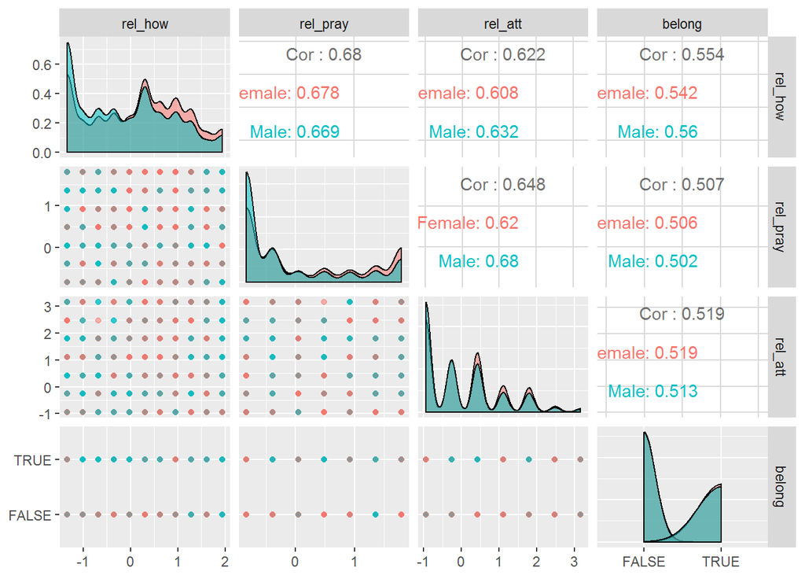

```r
p <- ggpairs(ESS, columns = 3:6, mapping = aes(col = gender, alpha = 0.3), lower = list(combo = wrap("facethist", bins = 20)))
p
```

Next I want to see the correlation between age and belonging to religion. As expected, the correlation is positive.

```r
ESS$belong_num<-as.numeric(ESS$belong)
#get correlation
cor.test (ESS$agea, ESS$belong_num, alternative = c ("two.sided"))
```

```
##
##  Pearson's product-moment correlation
##
## data:  ESS$agea and ESS$belong_num
## t = 14.051, df = 29608, p-value < 2.2e-16
## alternative hypothesis: true correlation is not equal to 0
## 95 percent confidence interval:
##  0.07006313 0.09269269
## sample estimates:
##       cor
## 0.0813884
```

### Logistic regression

Next I examine the earlier hypothesis with logistic regression. Dependent variable is the belonging to religion, and independent variables are the question how religious participant sees oneself, how often participant prays, how often participant attends to religious services, and the country, gender and age of the participants. Concerning the country, Finland is the reference group, and concerning the gender, women are the reference group.

Below we have the results of logistic regression. We see that all of the countries differ statistically significantly from Finland. All of the variables describing religious customs and how religious the participant sees oneself, are also associated with belonging to a religious group. Surprisingly, being male has weak but positive association with belonging to religion. As expected, age has positive association with belonging to religion.

```r
#logistic regression
ESS <- within(ESS, country <- relevel(country, ref = "Finland"))
logreg <- glm(belong ~ country + rel_how + rel_pray + rel_att + gender + agea, data = ESS, family = "binomial")
summary(logreg)
```

```
##
## Call:
## glm(formula = belong ~ country + rel_how + rel_pray + rel_att +
##     gender + agea, family = "binomial", data = ESS)
##
## Deviance Residuals:
##     Min       1Q   Median       3Q      Max
## -4.1776  -0.5848   0.0742   0.5703   2.8564
##
## Coefficients:
##                        Estimate Std. Error z value Pr(>|z|)
## (Intercept)           -0.505996   0.084241  -6.007 1.90e-09 ***
## countryAustria         1.341301   0.100531  13.342  < 2e-16 ***
## countryBelgium        -0.278097   0.097081  -2.865 0.004176 **
## countryCzech Republic -1.342878   0.116948 -11.483  < 2e-16 ***
## countryDenmark         0.805491   0.096397   8.356  < 2e-16 ***
## countryEstonia        -0.404106   0.094175  -4.291 1.78e-05 ***
## countryFrance          0.207138   0.095284   2.174 0.029712 *
## countryGermany         0.760046   0.084392   9.006  < 2e-16 ***
## countryHungary         0.413374   0.098349   4.203 2.63e-05 ***
## countryIreland         0.714497   0.095230   7.503 6.24e-14 ***
## countryIsrael          5.946802   0.255541  23.271  < 2e-16 ***
## countryLithuania       1.708931   0.102106  16.737  < 2e-16 ***
## countryNetherlands    -0.409620   0.098897  -4.142 3.44e-05 ***
## countryNorway          0.551048   0.098566   5.591 2.26e-08 ***
## countryPoland          1.509124   0.134178  11.247  < 2e-16 ***
## countryPortugal        0.844786   0.117277   7.203 5.88e-13 ***
## countrySlovenia        0.360308   0.107092   3.364 0.000767 ***
## countrySpain           1.336971   0.093207  14.344  < 2e-16 ***
## countrySweden         -0.259980   0.100179  -2.595 0.009454 **
## countrySwitzerland     0.667155   0.099683   6.693 2.19e-11 ***
## countryUnited Kingdom  0.319116   0.093698   3.406 0.000660 ***
## rel_how                0.970376   0.023853  40.682  < 2e-16 ***
## rel_pray               0.389890   0.023773  16.401  < 2e-16 ***
## rel_att                0.884184   0.026062  33.927  < 2e-16 ***
## genderMale             0.078162   0.033409   2.340 0.019305 *
## agea                   0.006615   0.001191   5.552 2.83e-08 ***
## ---
## Signif. codes:  0 '***' 0.001 '**' 0.01 '*' 0.05 '.' 0.1 ' ' 1
##
## (Dispersion parameter for binomial family taken to be 1)
##
##     Null deviance: 40886  on 29609  degrees of freedom
## Residual deviance: 23283  on 29584  degrees of freedom
## AIC: 23335
##
## Number of Fisher Scoring iterations: 7
```

Below we have the odds ratios and their confidence intervals (95 %). As expected, having a religious image of self is associated positively with belonging to religion (OR=2.6). Similarly, frequency of praying (OR=1.5) and frequency of attending to religious services (OR=2.4) are associated positively with belonging to religion. Yet, praying seems less important part of belonging to religion than the other two variables.

As stated before, the difference between genders is small but statistically significant: men have slightly greater odds (OR=1.1) of belonging to religion than women. I was sure I accidentally coded the genders reversed but I double checked and this is not a coding mistake. In other studies (as far as I know) women tend to be slightly more religious than men, and that’s why I am puzzled.

As stated earlier, age has positive association with religiousness: each year increases the odds of belonging to religion by 0.7%.

```r
#odds ratios and the confidence intervalls (95 %)
OR <- coef(logreg) %>% exp
CI <- confint(logreg) %>% exp
cbind(OR, CI)
```

```
##                                OR       2.5 %      97.5 %
## (Intercept)             0.6029046   0.5110276   0.7109953
## countryAustria          3.8240144   3.1418269   4.6595228
## countryBelgium          0.7572232   0.6258287   0.9156786
## countryCzech Republic   0.2610932   0.2072513   0.3278153
## countryDenmark          2.2377958   1.8527897   2.7036367
## countryEstonia          0.6675737   0.5548967   0.8026978
## countryFrance           1.2301529   1.0205238   1.4826796
## countryGermany          2.1383742   1.8127351   2.5235594
## countryHungary          1.5119099   1.2467418   1.8332477
## countryIreland          2.0431589   1.6958301   2.4632878
## countryIsrael         382.5282070 239.0802706 655.3382168
## countryLithuania        5.5230549   4.5256697   6.7535042
## countryNetherlands      0.6639027   0.5467107   0.8056336
## countryNorway           1.7350697   1.4301817   2.1047780
## countryPoland           4.5227671   3.4858570   5.8993428
## countryPortugal         2.3274785   1.8507823   2.9311513
## countrySlovenia         1.4337704   1.1625376   1.7690474
## countrySpain            3.8074916   3.1726483   4.5720351
## countrySweden           0.7710667   0.6332757   0.9379055
## countrySwitzerland      1.9486859   1.6032678   2.3698530
## countryUnited Kingdom   1.3759114   1.1449849   1.6531949
## rel_how                 2.6389375   2.5187322   2.7656088
## rel_pray                1.4768187   1.4096990   1.5473896
## rel_att                 2.4210076   2.3007689   2.5482519
## genderMale              1.0812981   1.0128045   1.1545240
## agea                    1.0066365   1.0042889   1.0089906
```

### Testing the predictive power of the model

Next I test the predictive power of my model by calculating the proportion of correctly classified observations. The proportion of incorrectly classified observations is the error of my model. In the crosstable below we see the confusion matrix comparing the real and the predicted model.

```r
#predict the probability of belonging to religion
probabilities <- predict(logreg, type = "response")
#add the predicted probabilities to dataset
ESS <- mutate(ESS, probability = probabilities)
#use the probabilities to make a prediction of belonging to religion
ESS <- mutate(ESS, prediction = probability >0.5 )
table(religious = ESS$belong, prediction = ESS$prediction) %>% prop.table() %>% addmargins()
```

```
##          prediction
## religious      FALSE       TRUE        Sum
##     FALSE 0.38020939 0.08277609 0.46298548
##     TRUE  0.09537318 0.44164134 0.53701452
##     Sum   0.47558257 0.52441743 1.00000000
```

In the plot below, the probability is on the x axis and belonging to religion is on the y axis.

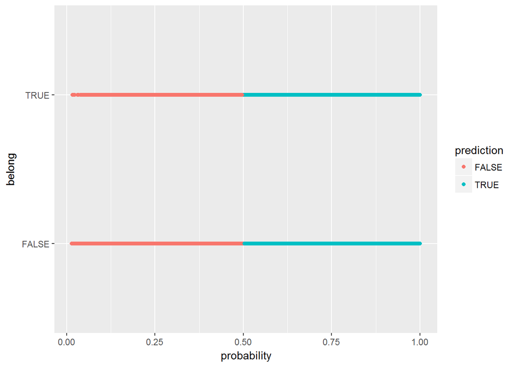

```r
g1 <- ggplot(ESS, aes(x = probability, y = belong, col=prediction))
g1 + geom_point()
```

Next I define a loss function and compute the mean prediction error for my model. Below we see that the training error of the model is 0.18. It means that, on average, 18 % of the predictions were wrong. Simple guessing method in a binary situation (e.g. flipping a symmetric coin) would have been right roughly in 50 % of the events. My model predicted accurately in 82 % of situations. Hence, my model performed better than just guessing. Still, interestingly, belonging to religion is complicated question: it seems to be something else than just the amount of praying, attending to religious services, and seeing oneself as religious.

```r
#define a loss function (mean prediction error)
loss_func <- function(class, prob) {
  n_wrong <- abs(class - prob) > 0.5
  mean(n_wrong)
}

#call loss_func to compute the average number of wrong predictions in the (training) data
loss_func(class = ESS$belong, prob = ESS$probability)
```

```
## [1] 0.1781493
```

### Cross-validation

As a last part of the assignment, I perform 10-fold cross-validation on my model. Cross-validation involves partitioning a sample of data into complementary subsets, performing the analysis on one subset (“the training set”), and validating the analysis on the other subset (“the testing set”). The process is repeated so that eventually all of the data is used for both the training and testing.

Delta gives two values: The first component is the raw cross-validation estimate of prediction error. The second component is the adjusted cross-validation estimate. The adjustment is designed to compensate for the bias introduced by not using leave-one-out cross-validation. Now they are both approximately 0.18. The training error estimated from the whole dataset was also 18 %. My model accurately predicted 82 % of the observations in the testing set.

```r
#perform 10-fold cross-validation by using earlier created loss function
cv <- cv.glm(data = ESS, cost = loss_func, glmfit = logreg, K = 10)
cv$delta
```

```
## [1] 0.1778116 0.1780446
```

## Conclusions

In this assignment, the religiousness of European working age population was studied by using the European Social Survey. Dependent variable was belonging to religion or denomination, and independent variables were having a religious image of self, frequency of praying and attending to religious services, country, gender, and age. Logistic regression was used for studying the associations.

As expected, having religious image of oneself, praying and attending to religious services were associated with belonging to religion, even when studied in the same model simultaneously. Yet, they were not equally important parts of belonging to religion: having a religious image of oneself and attending to religious services had greater odds of belonging to religion than the frequency of praying. Countries differed with their religiousness: As expected, participants from Sweden, the Netherlands, Estonia and Czech Republic had smaller odds of belonging to religion than Finnish participants. Participants from Catholic countries, for instance, from Poland and Spain, had greater odds of belonging to religion. Contrary to my hypothesis, men had a slightly greater odds of belonging to religion than women. As expected, belonging to religion was more common among older participants. These variables predicted participants’ belonging to religion accurately in slightly more than 80 % of the situations. This indicates that belonging to religion is not explained only by seeing oneself religious, attending to services, and praying (or by the demographic variables either). Belonging to religion may have different meanings for different individuals in different countries.